# rosynek_lab08

### **Lab 08 - Optimization Methods (Gradient Descent)**

**Paige Rosynek**

11.2.2022

#### **Introduction**

In this lab, we will be implementing an iterative optimization method called gradient descent. The goal of gradient descent is to find a set of parameters that minimizes a given cost function by following the gradient of a function. The general steps for gradient descent is as follows:

```
i. Set appropriate cost function
ii. Choose initial model parameters
iii. For k iterations:
    - Compute the gradient (numerically) at the current model parameters
    - Choose the step size
    - Update the parameters using: parameters - (gradient * self.step_size)
    - If the change in the gradient is < the defined tolerance, stop; otherwise go to step iii
```

This lab includes 3 experiments. In Experiment 1 and 2, we will be using gradient descent on single-parameter functions in order to better visualize how the gradient descent algorithm works. Then in Experiment 3, we will be using gradient descent to find a set of parameters (mu, sigma) that minimize the cost of the gaussian distribution data set and then observe how the otimized parameters effect the accuracy of our model. The purpose of this lab is to implement and explore gradient descent and how it can be used to optimize parameters to improve the quality of our models.

#### 1. Reflect on the form and organization of our optimizer API. Specifically, discuss each of the methods and what role they serve. This discussion should include what arguments they accept, what the method returns, and why we might choose to separate out these specific methods into helper methods.

The Optimizer constructor takes in the parameters:

- step_size : learning rate
- max_iter : maximum number of iterations to run to if optimal parameters are not found before
- tol : tolerance
- delta : change in parameter for computing the gradient (numerically)

The functions, _calculate_change, _gradient, and _update are private helper functions for the optimize function. It is beneficial to separate these operations into helper functions because it improves readability and allows for the optimizer to be tested according to its helper function. In other words, it is easier to debug if a step in the optimizer algorithm is incorrect. In addition, it is beneficial to separate the optimizer steps with helper functions because then we can reuse the different parts of the optimizer function for other things. The function _calculate_change() takes in two parameters: old parameters and new parameters. This function returns the norm of the difference between the old parameters and the updated (new) parameters which is the magnitude of the difference between the parameters, this value will be compared to the tolerance to determine whether or not to stop searching for optimal parameters within the optimize() function. The function _gradient() computes the numerical gradient. It takes in a cost fuction object (that implements the function cost()) and an array of model parameters. The gradient computes the partial derivative of the cost function with respect to each parameter in the given list of parameters numerically using the form: df/dx = [ f(x + delta) - f(x) ] / delta. The gradient approximates the derivative of the cost function w.r.t. the model parameters. The _update() function takes in a parameter vector and the gradient of the parameters then updates the parameter vector using the gradient descent algorithm. The function updates the parameters by subtracting the parameters by the product of the gradient and the stepsize then returns the updated parameters. Lastly, the optimize() function takes in a cost function object (that has the function cost() implemented) and the starting parameters. The function finds the optimal parameters that minimize the given cost function using gradient descent. The optimize() function runs until the maximum number of iterations is reached or the difference between the current and new parameters is less than the defined tolerance.

#### **For experiment 1:**

#### i. How many optima did you find? Hint: Discuss the significance of places where the derivative is equal to 0

In experiment 1, 2 optima were found by finding the x values where the derivative of the objective function is equal to (or really close to) zero. The x values where the derivative is equal to zero is where the slope of the tangent line of the function at the x value is zero, so this gives the x values where the function has a minima, maxima, or point of inflection. The two optima found in experiment 1 included both the minima and maxima of the objective function. The extrema of the function were found at the x values: x = -6.000000000000192 and x = 7.989999999999512, where x = 7.989999999999512 is the x value of the minima of the function.

#### ii. When you used the optimizer you started at x = 0. How many optima did your optimizer return? Was it a minima or maxima? Was it a global or local optima? By looking at the gradient descent algorithm find what term pointed you toward the minimum. Describe how it did this. Can you think of a way to find the function’s maxima?

The optimizer returned one optima with the optimized parameter (x value) of 7.99993677. This value was a local minima because the other ends of the equation go to poitive and negative infinity. The term in the gradient descent algorithm that points the algorithm toward the minimum is the gradient in the _update() function. The sign of the gradient for a parameter vector tells the direction of the step to take. It can be observed from the update step (param - (gradient *self.step_size)) that the product of the gradient and step size gets subtracted, and since the step size is always positive the sign of the term is determined by the gradient. An extrema is a minimum if the derivative to the left of the extrema is negative and the derivative to the right of it is positive. It can also be observed that when the gradient is negative, the step moves in the positive x direction (to the right) to move toward the minimum, which makes sense becuase a negative gradient means a negative slope so by increasing x it should get closer to the minimum. When the gradient is positive, it means that there is a positive slope at the given parameters, the step moves in the negative x direction (to the left) in order to move closer to the minimum. An extrema is a maxima where the derivative changes from positive to negative. In order to find the maxima of a function using this process, we can change the sign of the gradient in the update step such that the update step is: param + (gradient* self.step_size) so that for a positive gradient wer move to the right and for a negative gradient we move to the left to try to converge on a maxima.

#### ii. Describe the different starting locations that you used to solve for optima. Was the found optima different for any of these starting locations and were they the global or local optima? If it was, can you explain why the optimizer found different solutions?

Using the starting parameter, x = -2, the gradient descent algorithm found the local minimum of the function. The starting parameters of x = 3 and x = 6 found the global minimum. The optimizer found different solutions because the gradient descent algorithm moves down the negative slope until it finds a point where the derivative is equal or close to zero and stops (or until max iterations reached). Therefore, since the function has multiple minima, when the starting parameter is to the left of the local minima the algorithm goes until it finds the first minima it comes across which for x = -2 was the local minima.

#### **For experiment 3:**

#### i. How many optima did you find?

The optimizer found 1 optima; or one set of parameters that minimizes the cost function. The optimal parameters found were $\mu = 5.490459061464209$ and $\sigma = 1.2506876987679316$.

#### ii. Look back at the heatmaps you generated in Lab06 for the gaussian distribution. Describe what the optimizer is doing using the heatmap visualization.

Looking at the heatmap from Lab06, it can be observed that the optimizer is trying to find the set of parameters with the lowest error. It follows the heat map towards the darkest area, which is where the error is the lowest.

#### Import Libraries

```python
import numpy as np
import matplotlib.pyplot as plt
from numerical_differentiation import NumericalDifferentiation
from cost_functions import GaussianCostFunction
from optimizer import Optimizer
```

##### Test optimizer.py

```python
!python test_optim.py
```

```
......
----------------------------------------------------------------------
Ran 6 tests in 0.001s

OK
```

#### **Experiment 1 - Cubic Model**

$f(x) = x^3 - 3x^2 - 144x + 432$

```python
def f_cubic(x):
    return (x**3) - (3 * (x**2)) - (144 * x) + 432
```

##### 1. In the notebook, plot the cost function above within the bounds of -15 ≤ x ≤ 18 with a stepsize of 0.01. Observe the shape of this function and at what values of x the function has extrema.

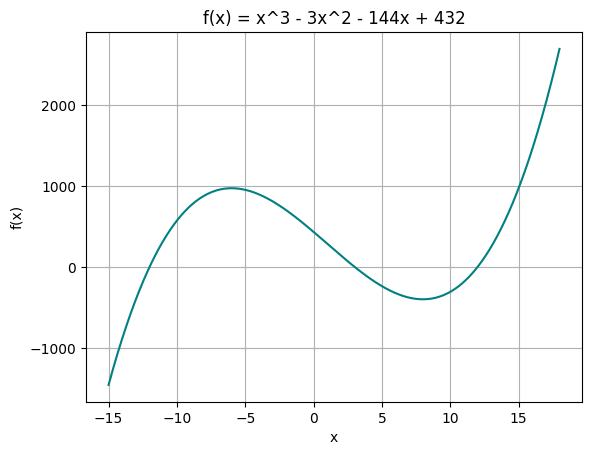

```python
xs = np.arange(-15, 18, 0.01)
plt.plot(xs, f_cubic(xs), c='teal')
plt.xlabel('x')
plt.ylabel('f(x)')
plt.title('f(x) = x^3 - 3x^2 - 144x + 432')
plt.grid(True)
plt.show()
```

##### 2. In a new figure, plot the numerical derivative of the cubic model within the same bounds and using the same step size. Search through the numerical derivative for the first 2 points of the that are equal (or closest) to zero.

```python
def numerical_diff(func, x, h):
    return (func(x + h) - func(x)) / h
```

Note: I assumed h = 0.01

```
Numerical derivative closest to zero at x = -6.000000000000192 and x = 7.989999999999512
derivative values : [-0.2099 -0.2099]
```

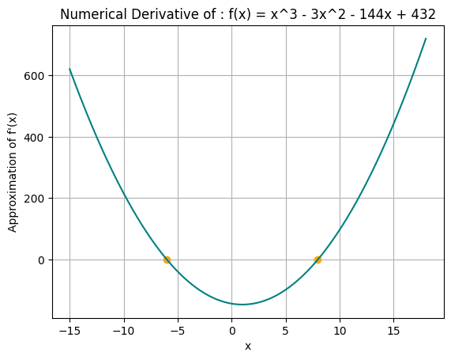

```python
xs = np.arange(-15, 18, 0.01)
h = 0.01
cubic_ndiff = numerical_diff(f_cubic, xs, h)

root_approx = np.argpartition(np.absolute(cubic_ndiff), kth=2)[:2]

print(f'Numerical derivative closest to zero at x = {xs[root_approx[0]]} and x = {xs[root_approx[1]]}')
print(f'derivative values : {cubic_ndiff[root_approx]}')

plt.plot(xs, cubic_ndiff, c='teal')
plt.scatter(xs[root_approx], cubic_ndiff[root_approx], c='orange', label='')
plt.xlabel('x')
plt.ylabel('Approximation of f\'(x)')
plt.title('Numerical Derivative of : f(x) = x^3 - 3x^2 - 144x + 432')
plt.grid(True)
plt.show()
```

##### 3. In a new cell in your notebook create a new objective function class. This class should implement the given objective function in a method called cost. Hint: Follow the cost_function API – but you will only need to implement the cost method.

```python
class CubicObjectiveFunction:
    def cost(self, params):
        return (params**3) - (3 * (params**2)) - (144 * params) + 432
```

#### 4. Import your optim classes, create an object with it, and supply the cost function that you wrote.

Use the following hyperparameters:

- Step_size = 0.01
- max_iter = 100
- tol = 1e-5
- delta = 1e-4

```python
optimizer = Optimizer(step_size=0.01, max_iter=100, tol=1e-5, delta=1e-4)
```

#### Using a starting point of 0, solve for the minimum using your optimizer. Plot a line from this starting point to the minima on your objective function plot.

```python
start_param = np.array([0.0])
(optimized_params, iters) = optimizer.optimize(cost_func=CubicObjectiveFunction(), starting_params=start_param)
print(f'starting params = {start_param}\t\toptimized_params = {optimized_params}\t\titerations = {iters}')
```

```
starting params = [0.]		optimized_params = [7.99993677]		iterations = 27
```

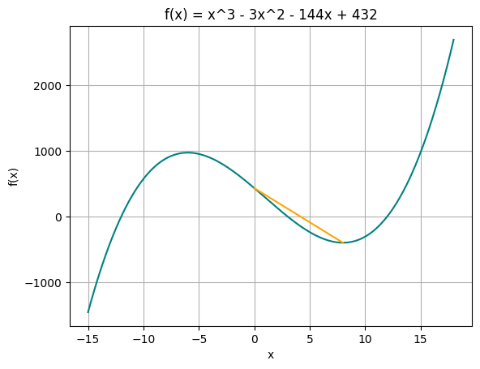

```python
xs = np.arange(-15, 18, 0.01)


plt.plot(xs, f_cubic(xs), c='teal')

plt.plot(np.array([start_param, optimized_params]), np.array([f_cubic(start_param), f_cubic(optimized_params)]), c='orange')

plt.xlabel('x')
plt.ylabel('f(x)')
plt.title('f(x) = x^3 - 3x^2 - 144x + 432')
plt.grid(True)
plt.show()
```

#### **Experiment 2 - Quartic Model**

**$f(x) = 3x^4 - 16x^3 - 18x^2$**

```python
def f_quartic(x):
    return (3 * (x**4)) - (16 * (x**3)) - (18 * (x**2))
```

#### 1. In the notebook, plot the cost function above within the bounds of -3 ≤ x ≤ 6.75 with a step size of 0.1. Observe the shape of this function and at what values of x the function has extrema.

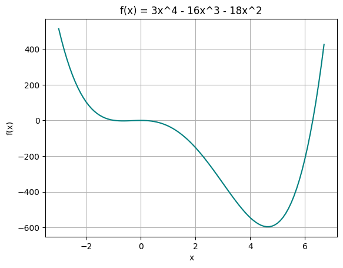

```python
xs = np.arange(-3, 6.75, 0.1)

plt.plot(xs, f_quartic(xs), c='teal')
plt.xlabel('x')
plt.ylabel('f(x)')
plt.title('f(x) = 3x^4 - 16x^3 - 18x^2')
plt.grid(True)
plt.show()
```

#### 2. In a new figure, plot the numerical derivative of the quartic model within the same bounds and using the same step size. Solve for the first 3 points of the derivative that are equal (or closest) to zero.

Note: I assumed h = 0.1

```
Numerical derivative closest to zero at x = 4.600000000000007 and x = -0.09999999999999742 and x = -0.699999999999998
derivative values : [ 1.355  1.637 -0.235]
```

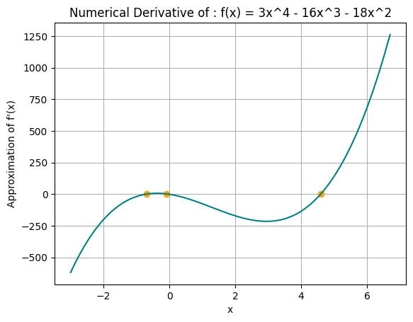

```python
h = 0.1
xs = np.arange(-3, 6.75, 0.1)
quartic_ndiff = numerical_diff(f_quartic, xs, h)

root_approx = np.argpartition(np.absolute(quartic_ndiff), kth=3)[:3]

print(f'Numerical derivative closest to zero at x = {xs[root_approx[0]]} and x = {xs[root_approx[1]]} and x = {xs[root_approx[2]]}')
print(f'derivative values : {quartic_ndiff[root_approx]}')

plt.plot(xs, quartic_ndiff, c='teal')
plt.scatter(xs[root_approx], quartic_ndiff[root_approx], c='orange')


plt.xlabel('x')
plt.ylabel('Approximation of f\'(x)')
plt.title('Numerical Derivative of : f(x) = 3x^4 - 16x^3 - 18x^2')
plt.grid(True)
plt.show()
```

#### 3. In a new cell in your notebook create a new objective function class. This class should implement the given objective function in a method called cost.

```python
class QuatricObjectiveFunction:
    def cost(self, params):
        return (3 * (params**4)) - (16 * (params**3)) - (18 * (params**2))
```

#### 4. Instantiate a new object with your optim class and supply the cost function that you wrote.

Use the following hyperparameters :

- Step_size = 0.001
- max_iter = 1000
- tol = 1e-5
- delta = 1e-4

```python
optimizer = Optimizer(step_size=0.001, max_iter=1000, tol=1e-5, delta=1e-4)
```

#### 5. Using the following three starting points, solve for the minimum using your optimizer. Plot a line from each of the starting points to the found minima on your objective function plot.

starting point :

- $x = 6$
- $x = 3$
- $x = -2$

```python
x_d = []
y_d = []
starting_params = np.array([[6.0], [3.0], [-2.0]])

for start in starting_params:
    (optimized_params, iters) = optimizer.optimize(cost_func=QuatricObjectiveFunction(), starting_params=start)
    print(f'starting param = {start}\t\toptimized_params = {optimized_params}\t\titerations = {iters}')
    x_d.append([start, optimized_params])
    y_d.append([f_quartic(start), f_quartic(optimized_params)])
```

```
starting param = [6.]		optimized_params = [4.64572056]		iterations = 30
starting param = [3.]		optimized_params = [4.64568186]		iterations = 36
starting param = [-2.]		optimized_params = [-0.64603101]		iterations = 176
```

```
No artists with labels found to put in legend.  Note that artists whose label start with an underscore are ignored when legend() is called with no argument.
```

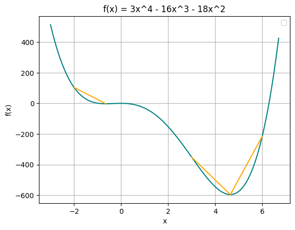

```python
xs = np.arange(-3, 6.75, 0.1)

plt.plot(xs, f_quartic(xs), c='teal')
plt.xlabel('x')
plt.ylabel('f(x)')
plt.title('f(x) = 3x^4 - 16x^3 - 18x^2')
plt.grid(True)

for x, y in zip(x_d, y_d):
    plt.plot(x, y, c='orange')

plt.legend()
plt.show()
```

#### **Experiment 3 - Gaussian Model**

#### 1. Import the gaussian distribution cost function that you created in the previous labs and instantiate it with the gaussdist.csv dataset.

```python
gauss = np.loadtxt('./data/gaussdist.csv', delimiter=',')

gauss_X = gauss[:,0]
gauss_y = gauss[:,1]
```

```python
gaussian_cost = GaussianCostFunction(gauss_X, gauss_y)
```

#### 2. Follow the presentation format from the previous labs in this notebook. Make sure to plot the data, initial model predictions, and the solved model predictions. Make sure to include in the plot the original error and the error after using the optimizer.

##### i) Plot the data

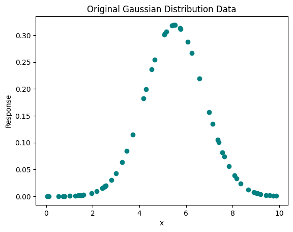

```python
plt.scatter(gauss_X, gauss_y, c='teal')
plt.title('Original Gaussian Distribution Data')
plt.xlabel('x')
plt.ylabel('Response')
plt.show()
```

##### ii) Plot initial model predicitions and error

parameters:

- $\mu = 1$
- $\sigma = 0.75$

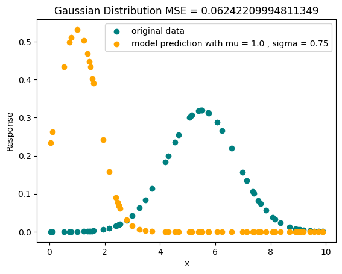

```python
init_params = np.array([1, 0.75])
y_pred = gaussian_cost.predict(gauss_X, init_params)
error = gaussian_cost.cost(init_params)

plt.scatter(gauss_X, gauss_y, c='teal', label='original data')
plt.scatter(gauss_X, y_pred, c='orange', label=f'model prediction with mu = {init_params[0]} , sigma = {init_params[1]}')

plt.title(f'Gaussian Distribution MSE = {error}')
plt.xlabel('x')
plt.ylabel('Response')
plt.legend()
plt.show()
```

#### iii) Find optimal parameters ($\mu, \sigma$)

use the hyperparameters :

- step_size = 1
- max_iter = 5000
- tol = 1e-4
- delta = 1e-3

with the starting params :

- $\mu = 1$
- $\sigma = 0.75$

```python
start_params = np.array([1, 0.75])
optimizer = Optimizer(step_size=1, max_iter=5000, tol=1e-4, delta=1e-3)
(optimized_params, iters) = optimizer.optimize(gaussian_cost, start_params)
print(f'optimized_params : mu = {optimized_params[0]}\tsigma = {optimized_params[1]}\titerations = {iters}')
```

```
optimized_params : mu = 5.490459061464209	sigma = 1.2506876987679316	iterations = 3031
```

##### iv) Plot model predictions with optimized parameters

- $\mu = 5.490459061464209$
- $\sigma = 1.2506876987679316$

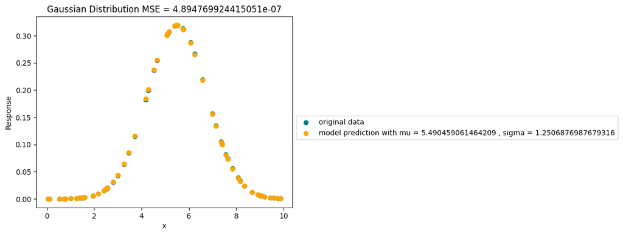

```python
y_pred_opt = gaussian_cost.predict(gauss_X, optimized_params)
opt_error = gaussian_cost.cost(optimized_params)

plt.scatter(gauss_X, gauss_y, c='teal', label='original data')
plt.scatter(gauss_X, y_pred_opt, c='orange', label=f'model prediction with mu = {optimized_params[0]} , sigma = {optimized_params[1]}')

plt.title(f'Gaussian Distribution MSE = {opt_error}')
plt.xlabel('x')
plt.ylabel('Response')
plt.legend(bbox_to_anchor=(1, 0.5), loc='upper left')
plt.show()
```